# Jordan Hope Groups Analysis

## 6.2 Multi-Group Ordered Categorical Model with participant effects

Let’s now fit theMulti-Group Model with participant effects.

```r
# define data in format needed for model specification
stan_data <- list()
stan_data$N <- nrow(dcat3)
stan_data$P <- max(dcat3$group)
stan_data$U <- max(dcat3$pid)
stan_data$K <- length(unique(dcat3$value))
stan_data$y <- dcat3$value
stan_data$group_of_obs <- dcat3$group
stan_data$unit_of_obs <- dcat3$pid

# sample
vac_ordered_categorical_logit_fit <- ordered_categorical_logit_compiled_m1$sample(
  data = stan_data,
  seed = 123,
  chains = 2,
  parallel_chains = 2,
  iter_warmup = 5e2,
  iter_sampling = 15e2,
  refresh = 500,
  save_warmup = TRUE
)
```

```
## Running MCMC with 2 parallel chains...
##
## Chain 1 Iteration:    1 / 2000 [  0%]  (Warmup)
## Chain 2 Iteration:    1 / 2000 [  0%]  (Warmup)
## Chain 2 Iteration:  500 / 2000 [ 25%]  (Warmup)
## Chain 2 Iteration:  501 / 2000 [ 25%]  (Sampling)
## Chain 1 Iteration:  500 / 2000 [ 25%]  (Warmup)
## Chain 1 Iteration:  501 / 2000 [ 25%]  (Sampling)
## Chain 2 Iteration: 1000 / 2000 [ 50%]  (Sampling)
## Chain 1 Iteration: 1000 / 2000 [ 50%]  (Sampling)
## Chain 2 Iteration: 1500 / 2000 [ 75%]  (Sampling)
## Chain 1 Iteration: 1500 / 2000 [ 75%]  (Sampling)
## Chain 2 Iteration: 2000 / 2000 [100%]  (Sampling)
## Chain 2 finished in 58.6 seconds.
## Chain 1 Iteration: 2000 / 2000 [100%]  (Sampling)
## Chain 1 finished in 59.7 seconds.
##
## Both chains finished successfully.
## Mean chain execution time: 59.1 seconds.
## Total execution time: 59.9 seconds.
```

```r
# save output to RDS
vac_ordered_categorical_logit_fit$save_object(file = file.path(dir.out, paste0(file.prefix,"m1_stan.rds")))
```

We see once more distinct participant-level effects that define participant-level latent factors:

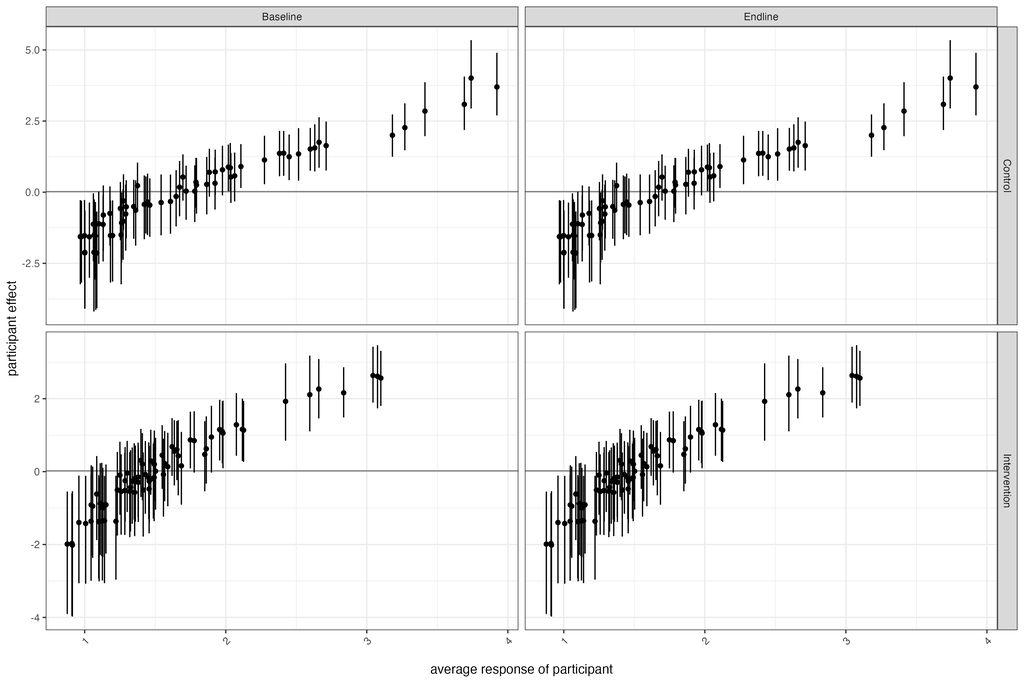

This is the model fit (in black) relative to the aggregated survey items. In this model, the participant level effects systematically influence the group-level outcome probabilities.

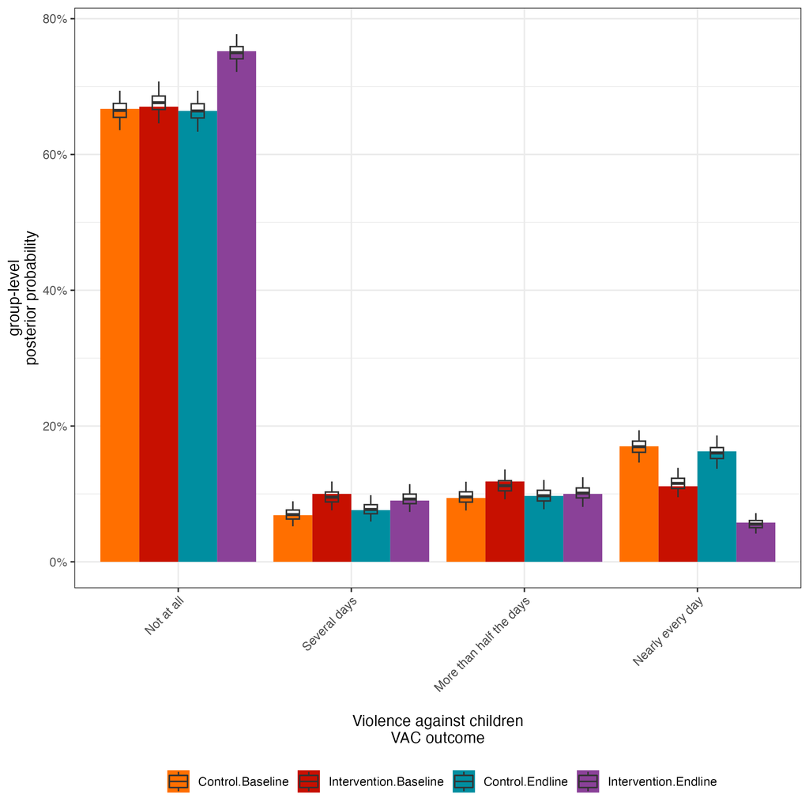

Here is a visualisation of the estimated polychoric correlations. We can clearly see that with participant effects, the model is already able to capture correlations between item responses.

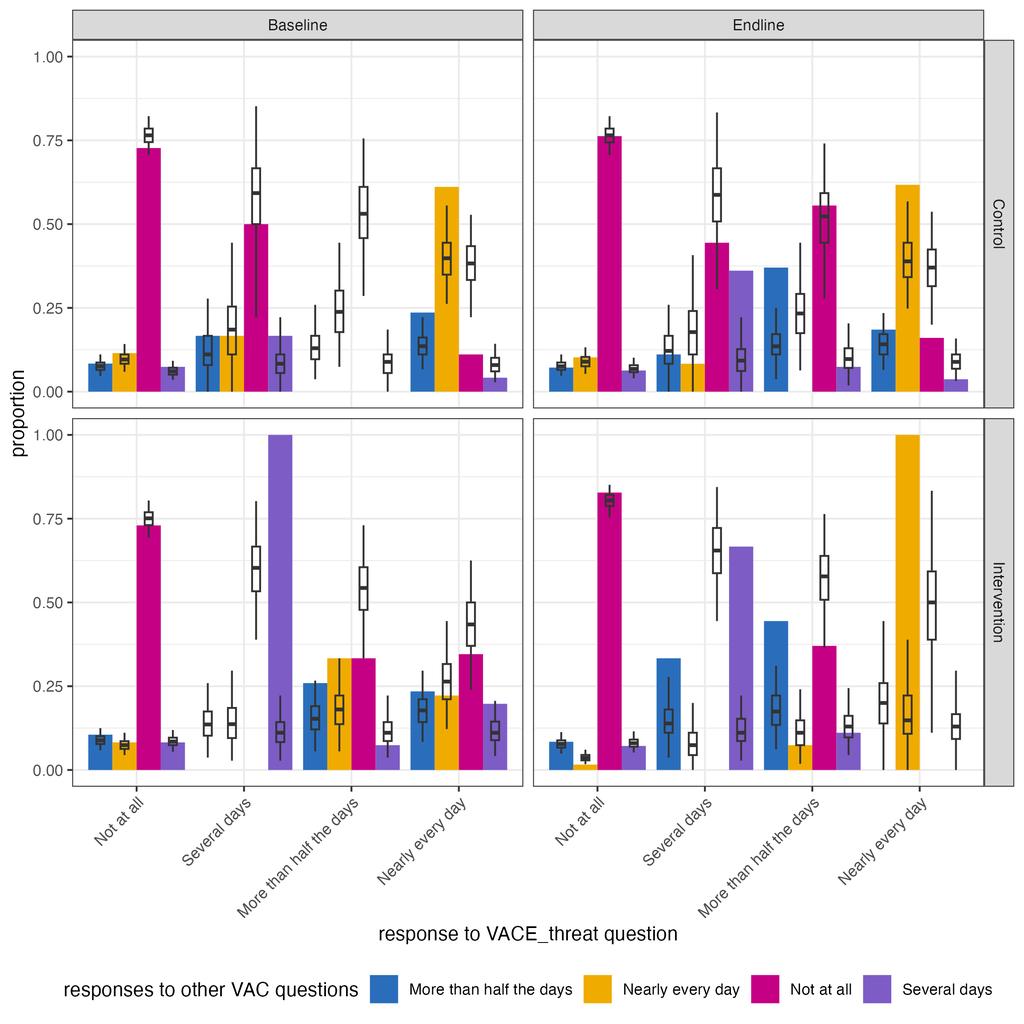

# 7 VAC - Poisson model

I will next consider the VAC Likert outcomes as if they were counts and aggregate these across all itemized questions that target the same behaviour.

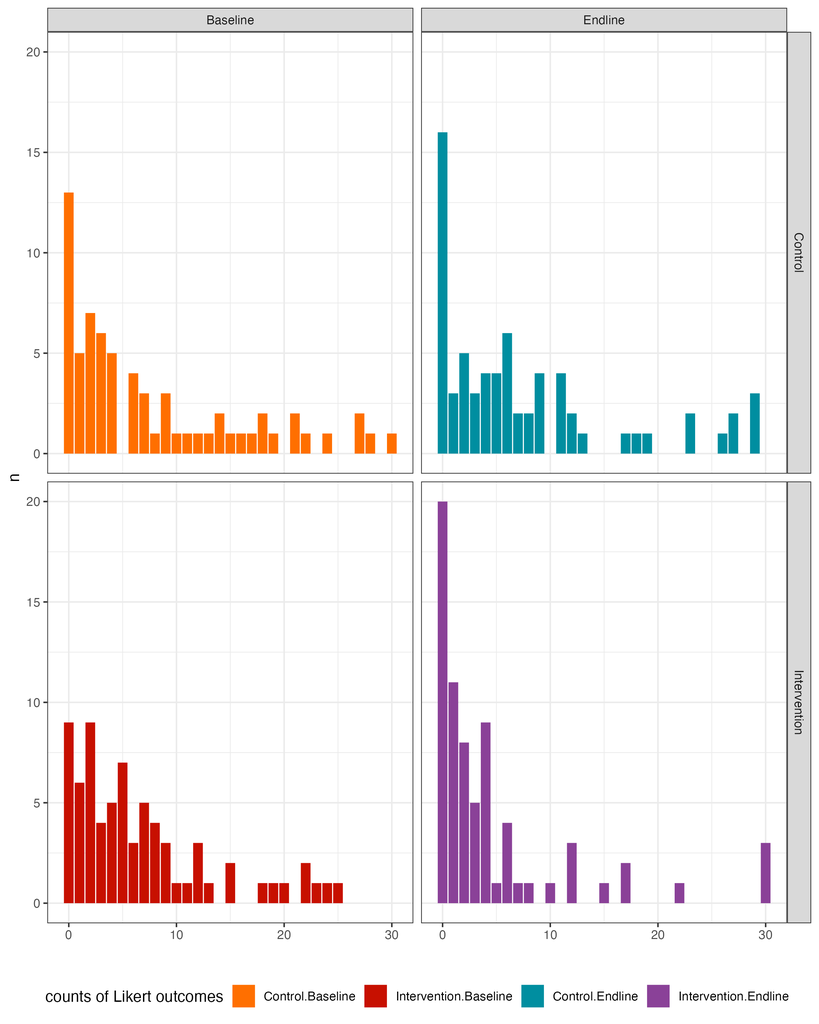

## 7.1 Model without participant effects

Let us fit the Poisson model.

This is the model fit to the aggregated Likert outcomes when considered as counts. With 10 questions targeting the same behaviour, it is immediately clear that the Poisson model provides an unacceptably poor fit to the aggregated data.

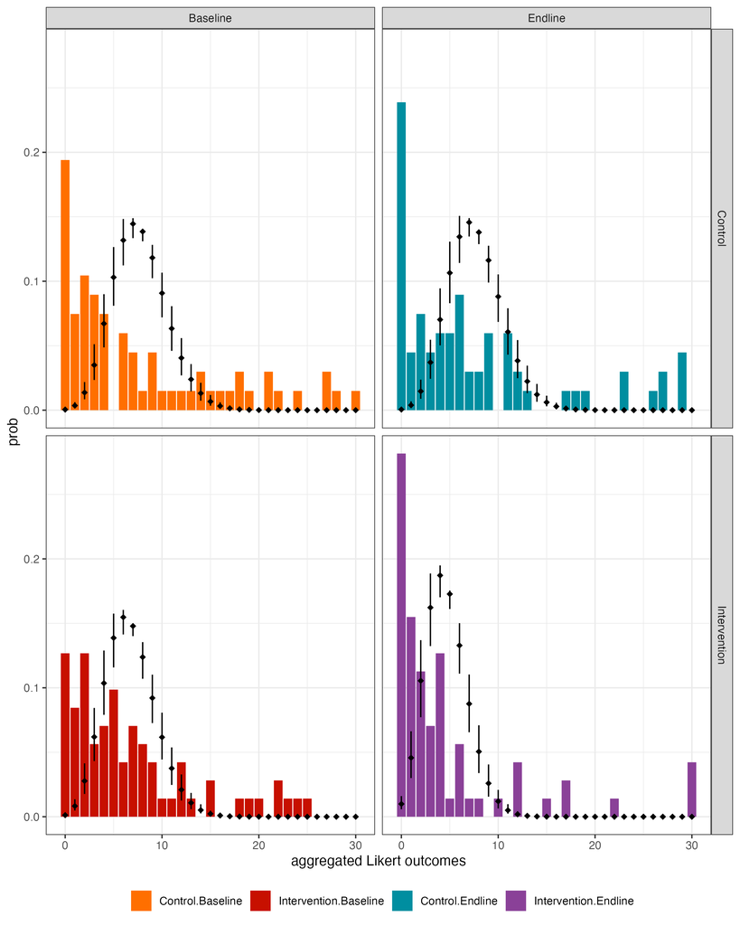

## 7.2 On Likert data for model comparison

I will now again consider the raw data for each survey question, but instead of interpreting these data as Likert scale outcomes, I will interpret these data as counts, and model these with a Poisson distribution.

I will start again with the model without participant effects.

We can see that the Poisson fit always follows a unimodal shape that does not capture the increasing trends in frequencies of the 2 and 3 category, particularly in the Control group.

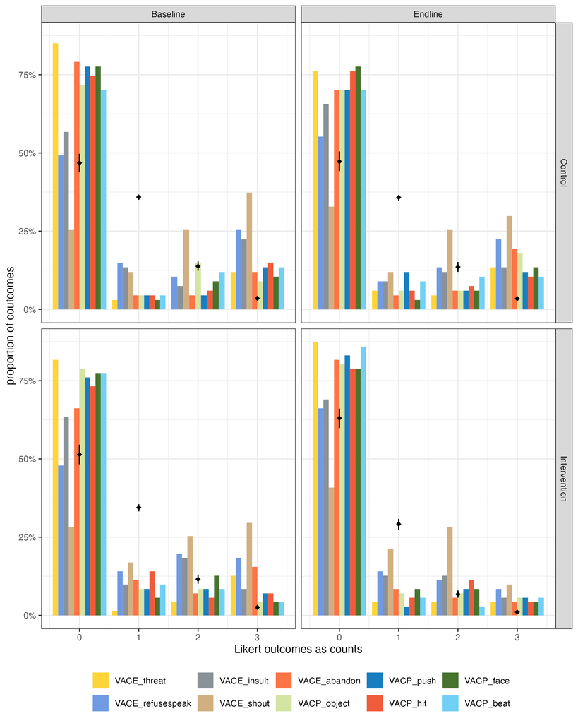

## 7.3 Model with participant effects

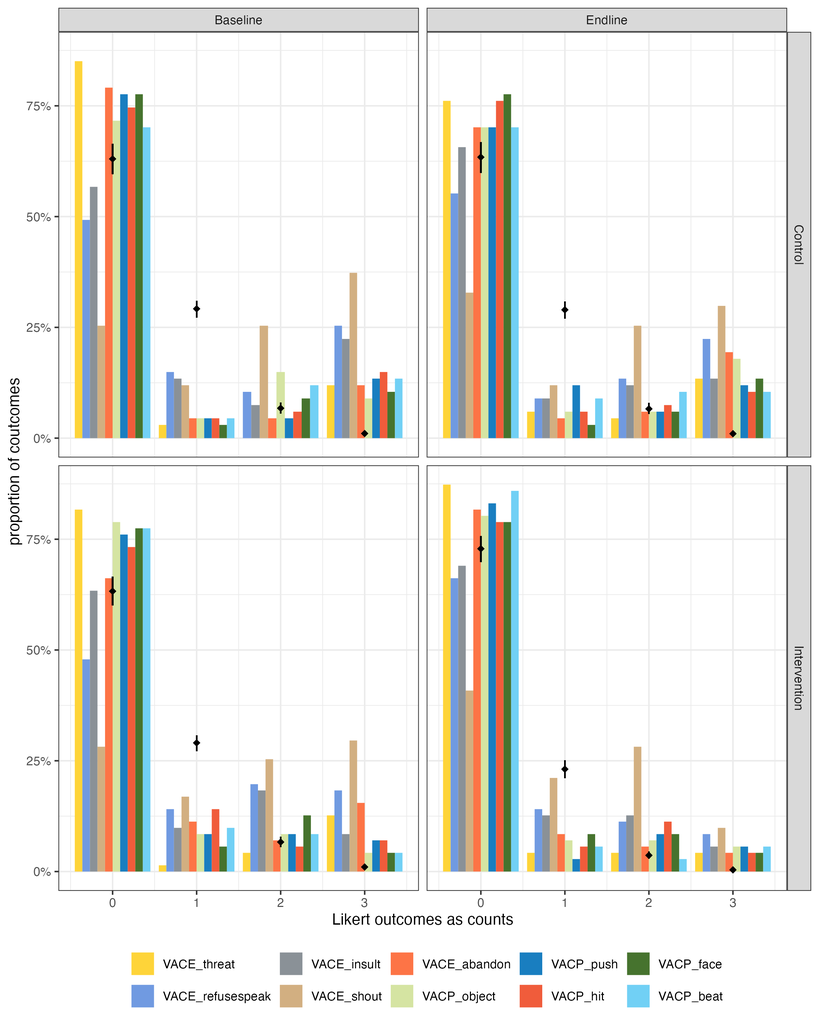

# 8 VAC - Ordered Cat Latent Factor model

```r
file.prefix <- 'vac_ordered_categorical_'

# define data in format needed for model specification
stan_data <- list()
stan_data$N <- nrow(dcat3)
stan_data$P <- max(dcat3$group)
stan_data$Q <- max(dcat3$vid)
stan_data$U <- max(dcat3$pid)
stan_data$K <- length(unique(dcat3$value))
stan_data$y <- dcat3$value
stan_data$group_of_obs <- dcat3$group
stan_data$question_of_obs <- dcat3$vid
stan_data$unit_of_obs <- dcat3$pid

# sample
vac_ordered_categorical_logit_fit_m5 <- ordered_categorical_logit_compiled_m5$sample(
  data = stan_data,
  seed = 123,
  chains = 2,
  parallel_chains = 2,
  iter_warmup = 5e2,
  iter_sampling = 15e2,
  refresh = 500,
  save_warmup = TRUE
)
```

```
## Running MCMC with 2 parallel chains...
##
## Chain 2 Iteration:    1 / 2000 [  0%]  (Warmup)
## Chain 1 Iteration:    1 / 2000 [  0%]  (Warmup)
## Chain 1 Iteration:  500 / 2000 [ 25%]  (Warmup)
## Chain 1 Iteration:  501 / 2000 [ 25%]  (Sampling)
## Chain 2 Iteration:  500 / 2000 [ 25%]  (Warmup)
## Chain 2 Iteration:  501 / 2000 [ 25%]  (Sampling)
## Chain 1 Iteration: 1000 / 2000 [ 50%]  (Sampling)
## Chain 2 Iteration: 1000 / 2000 [ 50%]  (Sampling)
## Chain 1 Iteration: 1500 / 2000 [ 75%]  (Sampling)
## Chain 2 Iteration: 1500 / 2000 [ 75%]  (Sampling)
## Chain 1 Iteration: 2000 / 2000 [100%]  (Sampling)
## Chain 1 finished in 106.7 seconds.
## Chain 2 Iteration: 2000 / 2000 [100%]  (Sampling)
## Chain 2 finished in 107.8 seconds.
##
## Both chains finished successfully.
## Mean chain execution time: 107.3 seconds.
## Total execution time: 108.1 seconds.
```

```r
# save output to RDS
vac_ordered_categorical_logit_fit_m5$save_object(file = file.path(dir.out, paste0(file.prefix,"m5_stan.rds")))
```

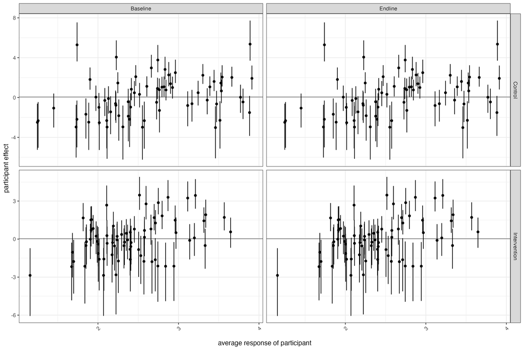

Here is the polychoric correlation plot:

[figure not shown]

Here is the model fit (in black) relative to the aggregated survey items. Hoorary, we have a good fit relative to our primary target statistics:

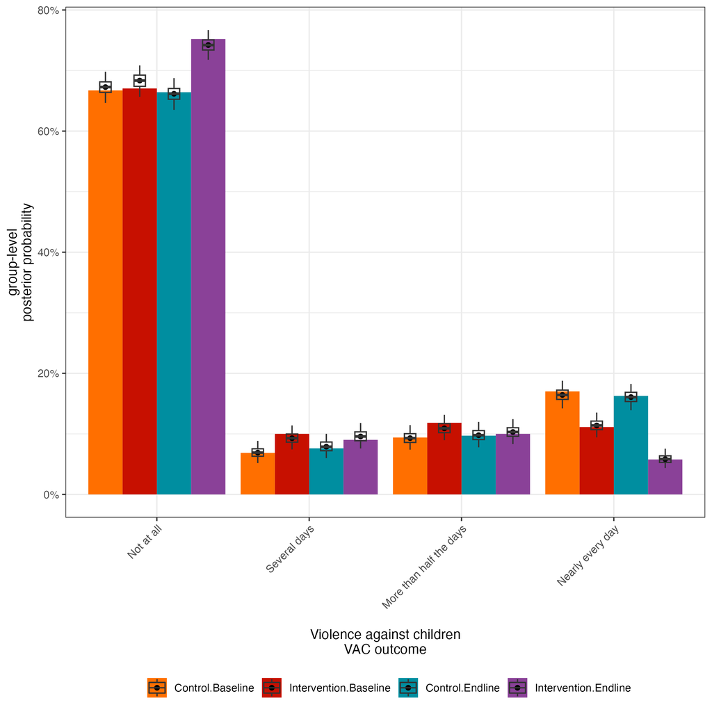

Here is the model fit (in black) relative to each survey item. We don’t achieve a super good fit, though perhaps fine.

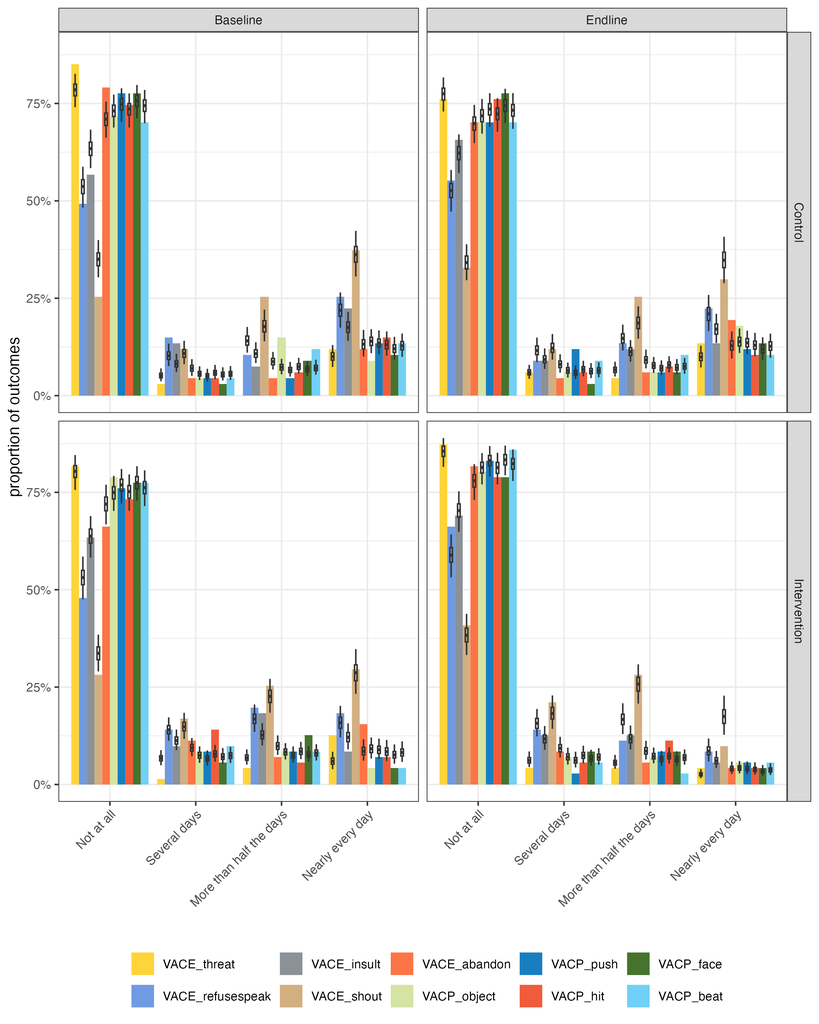

Here is a visualisation of the estimated polychoric correlations. We can clearly see how the model is inducing some correlations between item responses:

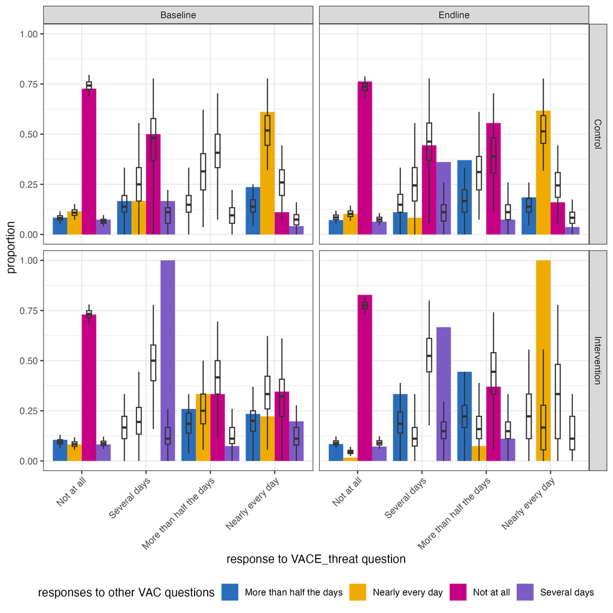

# 9 VAC - Compare models

Here is the model comparison in terms of Bayesian leave-one-out (Bayes-LOO) predictive performance measured by expected log posterior density (ELPD):

We see that the 1D latent factor model is the best performing model.

```r
# Model 1 - Poisson no participant effects
# Model 2 - Poisson with participant random effects
# Model 4 - Multi-group Ordered Cat, no participant effects
# Model 5 - Multi-group Ordered Cat, with participant random effects
# Model 9 - First Multi-group 1D Latent factor model
comp <- loo::loo_compare(vac_poisson_log_likert_fit_m0_loo,
                         vac_poisson_log_likert_fit_m1_loo,
                         vac_ordered_categorical_logit_fit_m0_loo,
                         vac_ordered_categorical_logit_fit_loo,
                         vac_ordered_categorical_logit_fit_m5_loo
                         )

print(comp, simplify = FALSE)
```

```
##        elpd_diff se_diff elpd_loo se_elpd_loo p_loo   se_p_loo looic   se_looic
## model5     0.0       0.0 -2067.8     47.0       139.6     5.1   4135.6    94.0
## model4  -194.8      20.3 -2262.6     48.5       126.7     3.8   4525.2    97.0
## model3  -555.3      28.3 -2623.1     46.2        12.0     0.3   5246.2    92.3
## model2  -715.5      38.0 -2783.3     57.1       169.8     7.3   5566.5   114.1
## model1 -1295.9      49.2 -3363.7     54.1         7.2     0.2   6727.4   108.1
```

# 10 Final analysis

## 10.1 Primary endpoints

The primary endpoint in this pre-post study is comparing the average change $\Delta_{g,f}$ in negative outcomes in the latent behavioral factors $f$ (parental mental health, violence against children) that occurr ‘Nearly every day’ between Baseline and Endline among the Intervention and Control groups $g \in \{I, C\}$, respectively. We will quantify the corresponding risk differences,
$$\begin{equation}
\text{RD}(f) = \Delta_{I,f} - \Delta_{C,f},
\end{equation}$$
for both the latent parental mental health and violence against children behaviours. Here, the average change $\Delta_{g,f}$ in the intervention and control groups is defined as
$$\begin{equation}
\Delta_{g,f} = \frac{1}{N_g}\sum_{i \in g} \frac{1}{J}\sum_j p^{f, t=0}_{i,j,k=4} - p^{f, t=1}_{i,k=4},
\end{equation}$$
where $p^{f, t=1}_{i,j,k=4}$ describes the probability of a ‘Nearly every day’ response ($k=4$) to survey item $j$ of participant $i$ at time $t$.

```r
# process Monte Carlo outputs

# process VAC
po <- vac_ordered_categorical_logit_fit_m5$draws(
  variables = c('ordered_prob_by_obs'),
  inc_warmup = FALSE,
  format = "draws_df"
  )
po <- as.data.table(po)
po <- data.table::melt(po, id.vars = c('.draw','.chain','.iteration'), value.name = 'prob')
po[, value := as.integer(gsub('ordered_prob_by_obs\\[([0-9]),([0-9]+)\\]','\\1',variable)) ]
po[, oid := as.integer(gsub('ordered_prob_by_obs\\[([0-9]),([0-9]+)\\]','\\2',variable)) ]
set(po, NULL, 'variable', NULL)
tmp <- unique(subset(dcat3, select = c(oid, pid, vid, group, arm, arm_label, time, time_label )))
po <- merge(po, tmp, by = c('oid'))
po <- subset(po, value == 4)
po <- data.table::dcast(po, .draw + pid + vid + arm + arm_label ~ time_label, value.var = 'prob')
po[, diff := Baseline - Endline]
po[, ratio := 1 - Endline / Baseline]
po <- po[, list(diff = mean(diff), ratio = mean(ratio)), by = c('.draw','arm','arm_label')]
po[, trait_label := 'Violence Against Children']
po.vac <- copy(po)

# process PHQ
po <- ordered_categorical_logit_fit_m5$draws(
  variables = c('ordered_prob_by_obs'),
  inc_warmup = FALSE,
  format = "draws_df"
  )
po <- as.data.table(po)
po <- data.table::melt(po, id.vars = c('.draw','.chain','.iteration'), value.name = 'prob')
po[, value := as.integer(gsub('ordered_prob_by_obs\\[([0-9]),([0-9]+)\\]','\\1',variable)) ]
po[, oid := as.integer(gsub('ordered_prob_by_obs\\[([0-9]),([0-9]+)\\]','\\2',variable)) ]
set(po, NULL, 'variable', NULL)
tmp <- unique(subset(dcat1, select = c(oid, pid, vid, group, arm, arm_label, time, time_label )))
po <- merge(po, tmp, by = c('oid'))
po <- subset(po, value == 4)
po <- data.table::dcast(po, .draw + pid + vid + arm + arm_label ~ time_label, value.var = 'prob')
po[, diff := Baseline - Endline]
po[, ratio := 1 - Endline / Baseline]
po <- po[, list(diff = mean(diff), ratio = mean(ratio)), by = c('.draw','arm','arm_label')]
po[, trait_label := 'Parental Mental Health']
po.pmh <- copy(po)
```

I first plot the average changes Endline versus Outline among participants in the Intervention and Control group:

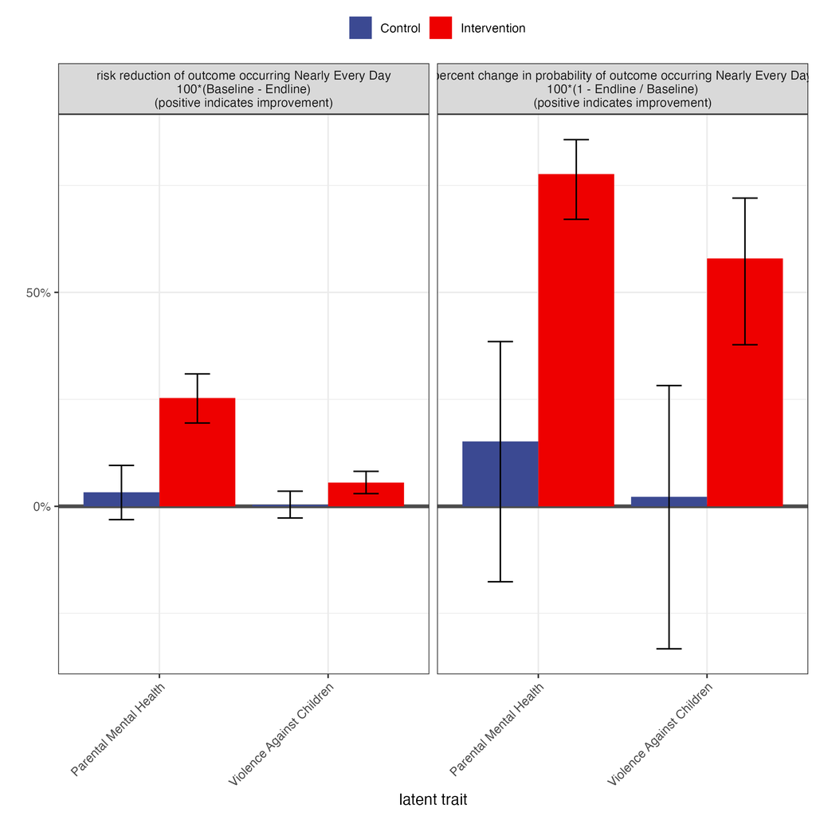

And here are the estimates of the primary endpoint for both Parental Mental Health and Violence Against Children:

```
## Key: <variable, trait_label>
##    variable               trait_label  iqr_lower  iqr_upper     median
##      <fctr>                    <char>      <num>      <num>      <num>
## 1:     diff    Parental Mental Health 0.18993899 0.24958385 0.22122330
## 2:     diff Violence Against Children 0.03737128 0.06576752 0.05226997
## 3:    ratio    Parental Mental Health 0.68567675 0.78107169 0.73881688
## 4:    ratio Violence Against Children 0.49241655 0.63930980 0.57018318
##       q_lower    q_upper                 label
##         <num>      <num>                <char>
## 1: 0.13263197 0.30254308 22.1% (13.3% - 30.3%)
## 2: 0.01330839 0.09324889    5.2% (1.3% - 9.3%)
## 3: 0.55801615 0.84646304 73.9% (55.8% - 84.6%)
## 4: 0.30843398 0.74264103   57% (30.8% - 74.3%)
```